# NFL Weekly Betting Study

# NFL Study

## Data Cleaning

### Entering Weekly Winners

A tie is treated as a scored game in which **both** sides lose the bet, and the game is **omitted** from % correct and Brier calculations.

## Attrition

Game-Level Data by Week

| Week | Participants | Games | Rows |
| --- | --- | --- | --- |
| 1 | 288 | 14 | 4046 |
| 2 | 281 | 15 | 4215 |
| 3 | 285 | 15 | 4275 |
| 4 | 282 | 15 | 4230 |
| 5 | 271 | 14 | 3794 |
| 6 | 257 | 13 | 3341 |
| 7 | 247 | 13 | 3211 |
| 8 | 248 | 13 | 3224 |
| 9 | 236 | 14 | 3304 |
| 10 | 229 | 13 | 2977 |

Out of 326 eligible participants (163 per condition).

Completion by Week

| Week | Odds Shown | Odds Shown % | No Odds | No Odds % | Total | Total % |
| --- | --- | --- | --- | --- | --- | --- |
| 1 | 146.0 | 89.6% | 142.0 | 87.1% | 288.0 | 88.3% |
| 2 | 140.0 | 85.9% | 141.0 | 86.5% | 281.0 | 86.2% |
| 3 | 144.0 | 88.3% | 141.0 | 86.5% | 285.0 | 87.4% |
| 4 | 141.0 | 86.5% | 141.0 | 86.5% | 282.0 | 86.5% |
| 5 | 134.0 | 82.2% | 137.0 | 84.0% | 271.0 | 83.1% |
| 6 | 126.0 | 77.3% | 131.0 | 80.4% | 257.0 | 78.8% |
| 7 | 124.0 | 76.1% | 123.0 | 75.5% | 247.0 | 75.8% |
| 8 | 124.0 | 76.1% | 124.0 | 76.1% | 248.0 | 76.1% |
| 9 | 122.0 | 74.8% | 114.0 | 69.9% | 236.0 | 72.4% |
| 10 | 117.0 | 71.8% | 112.0 | 68.7% | 229.0 | 70.2% |
| Mean | 131.8 | 80.9% | 130.6 | 80.1% | 262.4 | 80.5% |

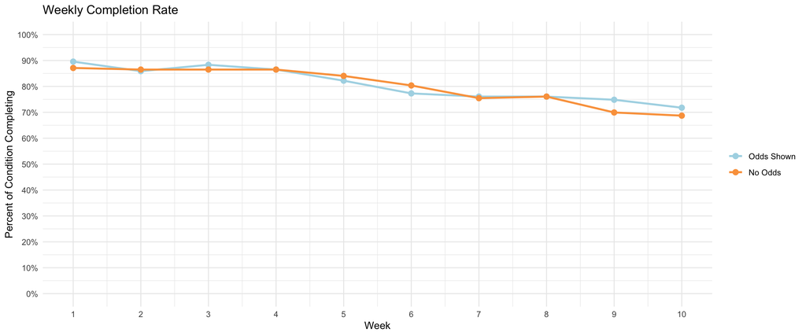

Number of Participants by Weeks Completed

| Weeks Completed | N Participants |
| --- | --- |
| 1 | 4 |
| 2 | 9 |
| 3 | 7 |
| 4 | 7 |
| 5 | 14 |
| 6 | 18 |
| 7 | 25 |
| 8 | 22 |
| 9 | 46 |
| 10 | 161 |
| Total | 313 |

## Incentives

### Weekly Incentive Summary

Incentives by Week (fee columns include the 1.33x Prolific charge)

| Week | N | NPaid | % Paid | MeanTokens | MeanPayout | Without Prolific Fee MeanPayment | Without Prolific Fee MaxPayment | Without Prolific Fee TotalPaid | With Prolific Fee MeanPaymentWithFee | With Prolific Fee MaxPaymentWithFee | With Prolific Fee TotalPaidWithFee |
| --- | --- | --- | --- | --- | --- | --- | --- | --- | --- | --- | --- |
| 1 | 288 | 125 | 43.4% | 89.8 | 12.1 | $0.12 | $1.75 | $34.73 | $0.16 | $2.33 | $46.17 |
| 2 | 281 | 115 | 40.9% | 96.6 | 18.6 | $0.19 | $2.95 | $52.39 | $0.25 | $3.92 | $69.71 |
| 3 | 285 | 107 | 37.5% | 87.4 | 16.7 | $0.17 | $1.54 | $47.59 | $0.22 | $2.05 | $63.32 |
| 4 | 282 | 148 | 52.5% | 107.9 | 28.0 | $0.28 | $2.45 | $79.05 | $0.37 | $3.26 | $105.18 |
| 5 | 271 | 133 | 49.1% | 97.8 | 23.1 | $0.23 | $1.50 | $62.49 | $0.31 | $2.00 | $83.21 |
| 6 | 257 | 116 | 45.1% | 101.3 | 27.8 | $0.28 | $5.50 | $71.44 | $0.37 | $7.32 | $95.03 |
| 7 | 247 | 76 | 30.8% | 82.2 | 21.3 | $0.21 | $3.80 | $52.57 | $0.28 | $5.05 | $69.91 |
| 8 | 248 | 134 | 54.0% | 100.4 | 23.3 | $0.23 | $2.45 | $57.76 | $0.31 | $3.26 | $76.86 |
| 9 | 236 | 134 | 56.8% | 90.4 | 22.3 | $0.22 | $1.42 | $52.55 | $0.30 | $1.89 | $69.96 |
| 10 | 229 | 143 | 62.4% | 115.3 | 34.3 | $0.34 | $1.95 | $78.46 | $0.46 | $2.59 | $104.39 |

Cumulative Incentive Cost — All Weeks

| Total (Without Prolific Fee) | Total (With Prolific Fee) |
| --- | --- |
| $589.03 | $783.74 |

## Demographics

### Age

Age

| Mean | SD | Min | Median | Max |
| --- | --- | --- | --- | --- |
| 39.87 | 11.35 | 18 | 38.5 | 72 |

### Categorical Demographics

Sex

| Response | N | Percent |
| --- | --- | --- |
| Male | 226 | 69.3% |
| Female | 100 | 30.7% |

Education

| Response | N | Percent |
| --- | --- | --- |
| Bachelor's or 4 year degree (ex. BA, BS) | 151 | 46.3% |
| Some college, no degree | 54 | 16.6% |
| Associate degree (ex. AA, AS) | 36 | 11.0% |
| High school graduate or equivalent (ex. GED) | 36 | 11.0% |
| Masters degree (ex. MA, MS, MBA) | 34 | 10.4% |
| Doctorate or Professional degree (eg. PhD, MD, JD, DDS, EdD) | 15 | 4.6% |

Race / Ethnicity

| Response | N | Percent |
| --- | --- | --- |
| White (Non-Hispanic) | 183 | 56.1% |
| White (Hispanic) | 46 | 14.1% |
| African American or Black | 44 | 13.5% |
| East Asian | 21 | 6.4% |
| Other | 11 | 3.4% |
| Non-White Hispanic | 10 | 3.1% |
| South Asian | 6 | 1.8% |
| American Indian or Alaskan Native | 2 | 0.6% |
| Native Hawaiian or Other Pacific Islander | 2 | 0.6% |
| Middle Eastern or North African | 1 | 0.3% |

Financial Wellbeing

| Response | N | Percent |
| --- | --- | --- |
| I have a little left over after basic needs | 95 | 29.1% |
| I am somewhat financially comfortable | 86 | 26.4% |
| I am financially comfortable | 85 | 26.1% |
| I can just meet basic needs | 37 | 11.3% |
| I am financially well-off | 12 | 3.7% |
| I struggle to meet basic needs | 11 | 3.4% |

Played Football Before

| Response | N | Percent |
| --- | --- | --- |
| No | 202 | 62.0% |
| Yes | 124 | 38.0% |

Relationship Watching the NFL

| Response | N | Percent |
| --- | --- | --- |
| I watch several games per week | 261 | 80.1% |
| I watch a game or two most weeks | 65 | 19.9% |

Sportsbook Experience

| Response | N | Percent |
| --- | --- | --- |
| I bet regularly, placing at least one bet a week | 104 | 31.9% |
| I bet casually, placing a bet a few times per month | 72 | 22.1% |
| I have placed a few bets but don't do it regularly | 68 | 20.9% |
| I have never placed a bet using a sportsbook | 67 | 20.6% |
| I would describe myself as a serious or professional bettor | 15 | 4.6% |

Prediction Market Experience

| Response | N | Percent |
| --- | --- | --- |
| I have never used a prediction market | 143 | 43.9% |
| I have used them a few times but don't do it regularly | 83 | 25.5% |
| I use one regularly, entering a contract at least once a week | 50 | 15.3% |
| I use one casually, entering contracts a few times per month | 41 | 12.6% |
| I would describe myself as a serious or professional trader on these platforms | 9 | 2.8% |

## Brier Scores

Brier Score Decomposition by Condition

| Week | Odds Shown N | Odds Shown Brier | Odds Shown Reliability | Odds Shown Resolution | Odds Shown Uncertainty | No Odds N | No Odds Brier | No Odds Reliability | No Odds Resolution | No Odds Uncertainty |
| --- | --- | --- | --- | --- | --- | --- | --- | --- | --- | --- |
| 1 | 2058 | 0.225 | 0.013 | 0.012 | 0.224 | 1988 | 0.230 | 0.014 | 0.009 | 0.226 |
| 2 | 2100 | 0.253 | 0.023 | 0.010 | 0.240 | 2115 | 0.252 | 0.018 | 0.006 | 0.240 |
| 3 | 2160 | 0.267 | 0.030 | 0.012 | 0.249 | 2115 | 0.266 | 0.031 | 0.014 | 0.250 |
| 4 | 2115 | 0.230 | 0.008 | 0.016 | 0.238 | 2115 | 0.227 | 0.008 | 0.016 | 0.236 |
| 5 | 1742 | 0.223 | 0.006 | 0.013 | 0.231 | 1781 | 0.221 | 0.008 | 0.015 | 0.228 |
| 6 | 1638 | 0.265 | 0.026 | 0.006 | 0.245 | 1703 | 0.264 | 0.027 | 0.007 | 0.245 |
| 7 | 1612 | 0.265 | 0.027 | 0.008 | 0.246 | 1599 | 0.276 | 0.034 | 0.006 | 0.248 |
| 8 | 1612 | 0.212 | 0.006 | 0.017 | 0.223 | 1612 | 0.216 | 0.007 | 0.014 | 0.223 |
| 9 | 1708 | 0.173 | 0.030 | 0.018 | 0.161 | 1596 | 0.166 | 0.036 | 0.020 | 0.150 |
| 10 | 1521 | 0.196 | 0.007 | 0.019 | 0.208 | 1456 | 0.200 | 0.018 | 0.017 | 0.199 |

Brier Score Decomposition — Overall

| Week | N | Brier | Reliability | Resolution | Uncertainty |
| --- | --- | --- | --- | --- | --- |
| 1 | 4046 | 0.227 | 0.011 | 0.008 | 0.225 |
| 2 | 4215 | 0.253 | 0.017 | 0.005 | 0.240 |
| 3 | 4275 | 0.267 | 0.028 | 0.011 | 0.250 |
| 4 | 4230 | 0.229 | 0.006 | 0.014 | 0.237 |
| 5 | 3523 | 0.222 | 0.004 | 0.011 | 0.229 |
| 6 | 3341 | 0.265 | 0.024 | 0.004 | 0.245 |
| 7 | 3211 | 0.270 | 0.027 | 0.004 | 0.247 |
| 8 | 3224 | 0.214 | 0.005 | 0.013 | 0.223 |
| 9 | 3304 | 0.170 | 0.032 | 0.018 | 0.156 |
| 10 | 2977 | 0.198 | 0.010 | 0.016 | 0.204 |

### Histograms

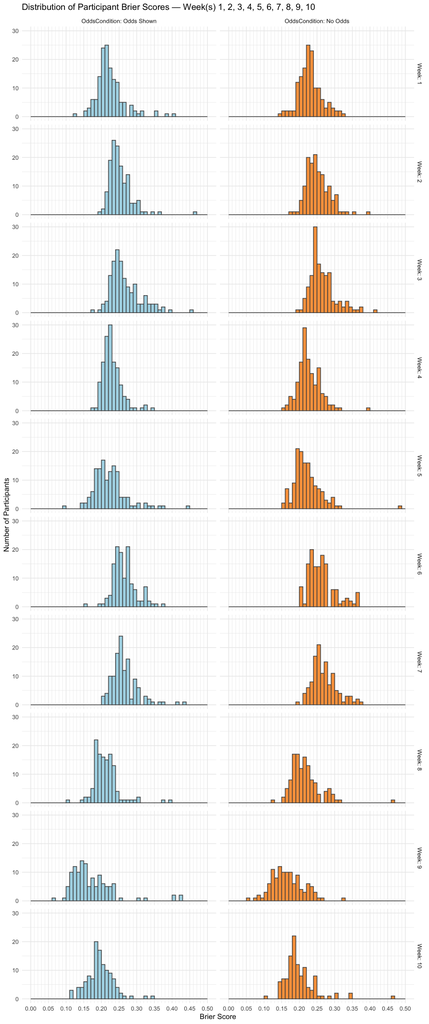

### Cumulative Density Functions

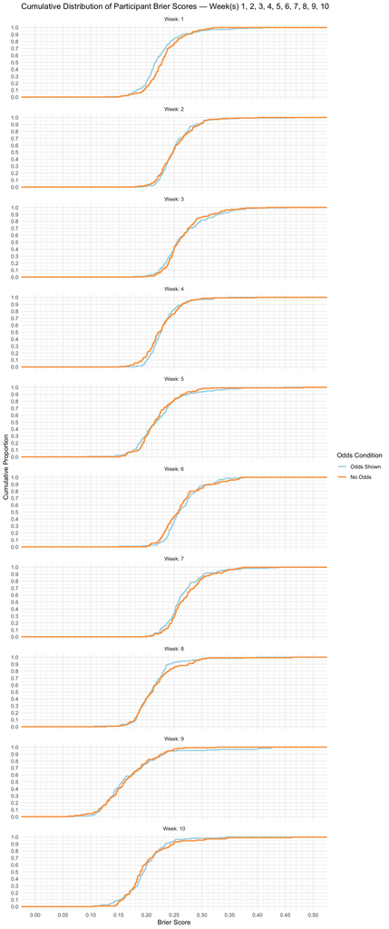

## Distribution of Bet Amounts (HHI)

Bet Concentration (HHI), Mean [95% CI]

| Week | Odds Shown | No Odds | Overall |
| --- | --- | --- | --- |
| 1 | 0.275 [0.232, 0.318] | 0.292 [0.245, 0.339] | 0.284 [0.252, 0.315] |
| 2 | 0.340 [0.290, 0.391] | 0.342 [0.288, 0.395] | 0.341 [0.304, 0.378] |
| 3 | 0.381 [0.325, 0.437] | 0.393 [0.335, 0.450] | 0.387 [0.347, 0.427] |
| 4 | 0.400 [0.343, 0.457] | 0.414 [0.355, 0.473] | 0.407 [0.366, 0.448] |
| 5 | 0.398 [0.337, 0.459] | 0.391 [0.335, 0.448] | 0.395 [0.353, 0.436] |
| 6 | 0.419 [0.358, 0.481] | 0.460 [0.394, 0.525] | 0.440 [0.395, 0.485] |
| 7 | 0.432 [0.369, 0.496] | 0.421 [0.357, 0.485] | 0.427 [0.382, 0.472] |
| 8 | 0.428 [0.364, 0.492] | 0.441 [0.375, 0.507] | 0.434 [0.389, 0.480] |
| 9 | 0.407 [0.343, 0.471] | 0.450 [0.380, 0.519] | 0.428 [0.381, 0.475] |
| 10 | 0.476 [0.409, 0.542] | 0.433 [0.366, 0.499] | 0.455 [0.408, 0.502] |

Reference: Minimum Possible HHI by Week

| Week | Games | Even-Split Floor |
| --- | --- | --- |
| 1 | 14 | 0.071 |
| 2 | 15 | 0.067 |
| 3 | 15 | 0.067 |
| 4 | 15 | 0.067 |
| 5 | 14 | 0.071 |
| 6 | 13 | 0.077 |
| 7 | 13 | 0.077 |
| 8 | 13 | 0.077 |
| 9 | 14 | 0.071 |
| 10 | 13 | 0.077 |

## Bet Consistency

Consistent Bets, Mean % [95% CI]

| Week | Odds Shown | No Odds | Overall |
| --- | --- | --- | --- |
| 1 | 68.2% [64.6, 71.8] | 63.3% [60.1, 66.5] | 65.8% [63.4, 68.2] |
| 2 | 56.5% [52.7, 60.3] | 54.0% [50.1, 57.9] | 55.3% [52.6, 58.0] |
| 3 | 63.7% [60.0, 67.4] | 62.3% [58.9, 65.7] | 63.0% [60.5, 65.5] |
| 4 | 59.9% [55.9, 63.9] | 55.7% [52.4, 59.1] | 57.8% [55.2, 60.4] |
| 5 | 62.5% [58.6, 66.4] | 59.0% [55.5, 62.6] | 60.8% [58.1, 63.4] |
| 6 | 63.3% [59.4, 67.2] | 61.9% [58.0, 65.8] | 62.6% [59.9, 65.3] |
| 7 | 59.8% [55.3, 64.3] | 61.5% [57.9, 65.2] | 60.7% [57.8, 63.5] |
| 8 | 55.8% [51.7, 60.0] | 54.9% [51.2, 58.6] | 55.4% [52.6, 58.1] |
| 9 | 51.4% [47.1, 55.7] | 50.6% [46.1, 55.0] | 51.0% [47.9, 54.1] |
| 10 | 54.6% [49.8, 59.4] | 51.0% [46.8, 55.1] | 52.8% [49.7, 56.0] |

Participants Consistent on Every Game

| Week | Odds Shown | No Odds | Overall |
| --- | --- | --- | --- |
| 1 | 6.8% | 2.8% | 4.9% |
| 2 | 1.4% | 2.1% | 1.8% |
| 3 | 2.1% | 3.5% | 2.8% |
| 4 | 5.7% | 2.1% | 3.9% |
| 5 | 3.0% | 2.9% | 3.0% |
| 6 | 4.0% | 4.6% | 4.3% |
| 7 | 3.2% | 5.7% | 4.5% |
| 8 | 2.4% | 2.4% | 2.4% |
| 9 | 4.9% | 4.4% | 4.7% |
| 10 | 3.4% | 1.8% | 2.6% |

## Division Win Likelihood

### Mean Likelihood by Team

Mean rating (0 to 100) for each team and week, one block of columns per group. “All weeks” pools every rating across weeks. Teams are sorted from highest to lowest on the Participants’ “All weeks” column. A dash means that group has no data for that week.

Mean Likelihood of Winning the Division, by Team, Week and Group

| Team | Division | Participants Week 6 | Participants Week 7 | Participants Week 8 | Participants Week 9 | Participants Week 10 | Participants All weeks | Opus Week 7 | Opus Week 8 | Opus Week 9 | Opus Week 10 | Opus All weeks | GPT Week 7 | GPT Week 8 | GPT Week 9 | GPT Week 10 | GPT All weeks |
| --- | --- | --- | --- | --- | --- | --- | --- | --- | --- | --- | --- | --- | --- | --- | --- | --- | --- |
| San Francisco 49ers | NFC West | 67.7% | 69.3% | 62.6% | 64.9% | 66.4% | 66.2% | 81.0% | 84.0% | 86.0% | 88.0% | 84.8% | 80.0% | 71.0% | 74.0% | 80.0% | 76.2% |
| Buffalo Bills | AFC East | 66.6% | 64.3% | 62.7% | 63.9% | 69.0% | 65.3% | 76.0% | 80.0% | 84.0% | 92.0% | 83.0% | 61.0% | 73.0% | 78.0% | 88.0% | 75.0% |
| Jacksonville Jaguars | AFC South | 61.5% | 53.6% | 61.8% | 64.1% | 68.2% | 61.7% | 74.0% | 85.0% | 94.0% | 95.0% | 87.0% | 68.0% | 76.0% | 82.0% | 87.0% | 78.2% |
| Kansas City Chiefs | AFC West | 69.8% | 67.0% | 60.0% | 53.8% | 52.6% | 60.9% | 72.0% | 58.0% | 40.0% | 39.0% | 52.2% | 66.0% | 59.0% | 44.0% | 42.0% | 52.8% |
| Minnesota Vikings | NFC North | 52.7% | 52.0% | 51.0% | 45.8% | 40.6% | 48.6% | 40.0% | 46.0% | 38.0% | 24.0% | 37.0% | 45.0% | 44.0% | 35.0% | 24.0% | 37.0% |
| Chicago Bears | NFC North | 34.3% | 43.5% | 41.6% | 48.4% | 47.4% | 42.9% | 24.0% | 22.0% | 29.0% | 36.0% | 27.8% | 20.0% | 22.0% | 32.0% | 36.0% | 27.5% |
| Denver Broncos | AFC West | 35.7% | 36.6% | 39.8% | 48.4% | 48.1% | 41.5% | 25.0% | 40.0% | 58.0% | 60.0% | 45.8% | 29.0% | 36.0% | 50.0% | 55.0% | 42.5% |
| New England Patriots | AFC East | 43.3% | 39.5% | 41.8% | 42.0% | 32.7% | 40.0% | 20.0% | 18.0% | 15.0% | 8.0% | 15.2% | 34.0% | 25.0% | 20.0% | 11.0% | 22.5% |
| Cincinnati Bengals | AFC North | 34.8% | 34.9% | 40.3% | 42.2% | 48.3% | 39.9% | 23.0% | 26.0% | 30.0% | 38.0% | 29.2% | 31.0% | 42.0% | 54.0% | 66.0% | 48.2% |
| Seattle Seahawks | NFC West | 38.2% | 39.1% | 43.9% | 40.7% | 37.1% | 39.8% | 14.0% | 13.0% | 7.0% | 6.0% | 10.0% | 12.0% | 19.0% | 14.0% | 10.0% | 13.8% |
| New York Giants | NFC East | 34.4% | 30.1% | 40.6% | 45.3% | 43.8% | 38.7% | 46.0% | 62.0% | 72.0% | 76.0% | 64.0% | 36.0% | 40.0% | 49.0% | 64.0% | 47.2% |
| Pittsburgh Steelers | AFC North | 33.2% | 35.4% | 39.1% | 44.9% | 40.2% | 38.5% | 27.0% | 29.0% | 42.0% | 40.0% | 34.5% | 13.0% | 15.0% | 31.0% | 27.0% | 21.5% |
| Detroit Lions | NFC North | 35.4% | 34.9% | 36.6% | 40.3% | 38.2% | 37.0% | 16.0% | 18.0% | 22.0% | 26.0% | 20.5% | 20.0% | 27.0% | 24.0% | 26.0% | 24.2% |
| Carolina Panthers | NFC South | 41.5% | 44.0% | 32.9% | 33.1% | 32.2% | 36.9% | 52.0% | 38.0% | 38.0% | 30.0% | 39.5% | 50.0% | 34.0% | 33.0% | 28.0% | 36.2% |
| Green Bay Packers | NFC North | 33.4% | 35.7% | 33.6% | 33.1% | 37.2% | 34.6% | 20.0% | 14.0% | 11.0% | 14.0% | 14.8% | 15.0% | 7.0% | 9.0% | 14.0% | 11.2% |
| Baltimore Ravens | AFC North | 52.6% | 40.8% | 34.8% | 18.4% | 20.0% | 33.8% | 27.0% | 17.0% | 4.0% | 4.0% | 13.0% | 48.0% | 30.0% | 5.0% | 3.0% | 21.5% |
| Dallas Cowboys | NFC East | 32.4% | 34.9% | 37.1% | 29.2% | 28.5% | 32.5% | 25.0% | 24.0% | 15.0% | 15.0% | 19.8% | 40.0% | 42.0% | 29.0% | 26.0% | 34.2% |
| Los Angeles Rams | NFC West | 39.1% | 28.3% | 29.4% | 31.5% | 30.7% | 31.9% | 2.0% | 2.0% | 6.0% | 6.0% | 4.0% | 7.0% | 9.0% | 11.0% | 9.0% | 9.0% |
| Atlanta Falcons | NFC South | 34.7% | 28.0% | 33.2% | 27.1% | 24.8% | 29.7% | 18.0% | 36.0% | 23.0% | 20.0% | 24.2% | 24.0% | 32.0% | 21.0% | 21.0% | 24.5% |
| Cleveland Browns | AFC North | 20.3% | 30.4% | 30.8% | 26.9% | 23.4% | 26.4% | 23.0% | 28.0% | 24.0% | 18.0% | 23.2% | 8.0% | 13.0% | 10.0% | 4.0% | 8.8% |
| Tampa Bay Buccaneers | NFC South | 18.3% | 18.9% | 27.0% | 29.3% | 27.6% | 24.1% | 12.0% | 14.0% | 25.0% | 21.0% | 18.0% | 12.0% | 18.0% | 30.0% | 36.0% | 24.0% |
| Houston Texans | AFC South | 19.1% | 29.8% | 20.8% | 23.6% | 23.4% | 23.3% | 12.0% | 7.0% | 3.0% | 4.0% | 6.5% | 24.0% | 19.0% | 16.0% | 11.0% | 17.5% |
| New Orleans Saints | NFC South | 21.3% | 22.2% | 18.8% | 21.5% | 24.7% | 21.7% | 18.0% | 12.0% | 14.0% | 29.0% | 18.2% | 14.0% | 16.0% | 16.0% | 15.0% | 15.2% |
| Philadelphia Eagles | NFC East | 35.0% | 23.0% | 16.5% | 15.9% | 14.1% | 21.2% | 19.0% | 8.0% | 4.0% | 1.0% | 8.0% | 11.0% | 7.0% | 4.0% | 1.0% | 5.8% |
| Washington Commanders | NFC East | 18.4% | 17.0% | 19.3% | 19.8% | 21.6% | 19.2% | 10.0% | 6.0% | 9.0% | 8.0% | 8.2% | 13.0% | 11.0% | 18.0% | 9.0% | 12.8% |
| Las Vegas Raiders | AFC West | 19.6% | 21.1% | 16.8% | 18.1% | 15.3% | 18.2% | 3.0% | 2.0% | 2.0% | 1.0% | 2.0% | 4.0% | 4.0% | 5.0% | 2.0% | 3.8% |
| Indianapolis Colts | AFC South | 26.4% | 19.5% | 14.5% | 13.3% | 13.6% | 17.6% | 9.0% | 5.0% | 2.0% | 1.0% | 4.2% | 7.0% | 4.0% | 1.0% | 1.0% | 3.2% |
| New York Jets | AFC East | 11.9% | 14.0% | 11.7% | 12.2% | 10.4% | 12.0% | 3.0% | 1.0% | 1.0% | 0.0% | 1.2% | 4.0% | 1.0% | 1.0% | 1.0% | 1.8% |
| Arizona Cardinals | NFC West | 10.1% | 13.9% | 10.8% | 12.9% | 10.5% | 11.6% | 3.0% | 1.0% | 1.0% | 0.0% | 1.2% | 1.0% | 1.0% | 1.0% | 1.0% | 1.0% |
| Los Angeles Chargers | AFC West | 10.7% | 12.0% | 9.5% | 10.7% | 10.7% | 10.7% | 0.0% | 0.0% | 0.0% | 0.0% | 0.0% | 1.0% | 1.0% | 1.0% | 1.0% | 1.0% |
| Tennessee Titans | AFC South | 8.9% | 11.0% | 9.7% | 10.6% | 9.8% | 10.0% | 5.0% | 3.0% | 1.0% | 0.0% | 2.2% | 1.0% | 1.0% | 1.0% | 1.0% | 1.0% |
| Miami Dolphins | AFC East | 7.8% | 8.3% | 8.6% | 9.7% | 8.8% | 8.6% | 1.0% | 1.0% | 0.0% | 0.0% | 0.5% | 1.0% | 1.0% | 1.0% | 0.0% | 0.8% |

### Division Tables and Sums

For each group, the 8 divisions with each team’s mean rating per week and a bold Sum row (red if above 100, blue if below).

Participants

AFC East

| Team | Week 6 | Week 7 | Week 8 | Week 9 | Week 10 |
| --- | --- | --- | --- | --- | --- |
| Buffalo Bills | 66.6% | 64.3% | 62.7% | 63.9% | 69.0% |
| New England Patriots | 43.3% | 39.5% | 41.8% | 42.0% | 32.7% |
| New York Jets | 11.9% | 14.0% | 11.7% | 12.2% | 10.4% |
| Miami Dolphins | 7.8% | 8.3% | 8.6% | 9.7% | 8.8% |
| **Sum** | 129.5% | 126.1% | 124.7% | 127.7% | 120.9% |

NFC East

| Team | Week 6 | Week 7 | Week 8 | Week 9 | Week 10 |
| --- | --- | --- | --- | --- | --- |
| New York Giants | 34.4% | 30.1% | 40.6% | 45.3% | 43.8% |
| Dallas Cowboys | 32.4% | 34.9% | 37.1% | 29.2% | 28.5% |
| Philadelphia Eagles | 35.0% | 23.0% | 16.5% | 15.9% | 14.1% |
| Washington Commanders | 18.4% | 17.0% | 19.3% | 19.8% | 21.6% |
| **Sum** | 120.2% | 105.0% | 113.5% | 110.2% | 108.0% |

AFC North

| Team | Week 6 | Week 7 | Week 8 | Week 9 | Week 10 |
| --- | --- | --- | --- | --- | --- |
| Cincinnati Bengals | 34.8% | 34.9% | 40.3% | 42.2% | 48.3% |
| Pittsburgh Steelers | 33.2% | 35.4% | 39.1% | 44.9% | 40.2% |
| Baltimore Ravens | 52.6% | 40.8% | 34.8% | 18.4% | 20.0% |
| Cleveland Browns | 20.3% | 30.4% | 30.8% | 26.9% | 23.4% |
| **Sum** | 140.9% | 141.5% | 145.0% | 132.4% | 132.0% |

NFC North

| Team | Week 6 | Week 7 | Week 8 | Week 9 | Week 10 |
| --- | --- | --- | --- | --- | --- |
| Minnesota Vikings | 52.7% | 52.0% | 51.0% | 45.8% | 40.6% |
| Chicago Bears | 34.3% | 43.5% | 41.6% | 48.4% | 47.4% |
| Detroit Lions | 35.4% | 34.9% | 36.6% | 40.3% | 38.2% |
| Green Bay Packers | 33.4% | 35.7% | 33.6% | 33.1% | 37.2% |
| **Sum** | 155.8% | 166.2% | 162.8% | 167.7% | 163.3% |

AFC South

| Team | Week 6 | Week 7 | Week 8 | Week 9 | Week 10 |
| --- | --- | --- | --- | --- | --- |
| Jacksonville Jaguars | 61.5% | 53.6% | 61.8% | 64.1% | 68.2% |
| Houston Texans | 19.1% | 29.8% | 20.8% | 23.6% | 23.4% |
| Indianapolis Colts | 26.4% | 19.5% | 14.5% | 13.3% | 13.6% |
| Tennessee Titans | 8.9% | 11.0% | 9.7% | 10.6% | 9.8% |
| **Sum** | 115.9% | 113.9% | 106.8% | 111.6% | 115.0% |

NFC South

| Team | Week 6 | Week 7 | Week 8 | Week 9 | Week 10 |
| --- | --- | --- | --- | --- | --- |
| Carolina Panthers | 41.5% | 44.0% | 32.9% | 33.1% | 32.2% |
| Atlanta Falcons | 34.7% | 28.0% | 33.2% | 27.1% | 24.8% |
| Tampa Bay Buccaneers | 18.3% | 18.9% | 27.0% | 29.3% | 27.6% |
| New Orleans Saints | 21.3% | 22.2% | 18.8% | 21.5% | 24.7% |
| **Sum** | 115.8% | 113.1% | 112.0% | 110.9% | 109.3% |

AFC West

| Team | Week 6 | Week 7 | Week 8 | Week 9 | Week 10 |
| --- | --- | --- | --- | --- | --- |
| Kansas City Chiefs | 69.8% | 67.0% | 60.0% | 53.8% | 52.6% |
| Denver Broncos | 35.7% | 36.6% | 39.8% | 48.4% | 48.1% |
| Las Vegas Raiders | 19.6% | 21.1% | 16.8% | 18.1% | 15.3% |
| Los Angeles Chargers | 10.7% | 12.0% | 9.5% | 10.7% | 10.7% |
| **Sum** | 135.7% | 136.7% | 126.0% | 131.1% | 126.7% |

NFC West

| Team | Week 6 | Week 7 | Week 8 | Week 9 | Week 10 |
| --- | --- | --- | --- | --- | --- |
| San Francisco 49ers | 67.7% | 69.3% | 62.6% | 64.9% | 66.4% |
| Seattle Seahawks | 38.2% | 39.1% | 43.9% | 40.7% | 37.1% |
| Los Angeles Rams | 39.1% | 28.3% | 29.4% | 31.5% | 30.7% |
| Arizona Cardinals | 10.1% | 13.9% | 10.8% | 12.9% | 10.5% |
| **Sum** | 155.1% | 150.6% | 146.7% | 150.0% | 144.7% |

Opus

AFC East

| Team | Week 7 | Week 8 | Week 9 | Week 10 |
| --- | --- | --- | --- | --- |
| Buffalo Bills | 76.0% | 80.0% | 84.0% | 92.0% |
| New England Patriots | 20.0% | 18.0% | 15.0% | 8.0% |
| New York Jets | 3.0% | 1.0% | 1.0% | 0.0% |
| Miami Dolphins | 1.0% | 1.0% | 0.0% | 0.0% |
| **Sum** | 100.0% | 100.0% | 100.0% | 100.0% |

NFC East

| Team | Week 7 | Week 8 | Week 9 | Week 10 |
| --- | --- | --- | --- | --- |
| New York Giants | 46.0% | 62.0% | 72.0% | 76.0% |
| Dallas Cowboys | 25.0% | 24.0% | 15.0% | 15.0% |
| Washington Commanders | 10.0% | 6.0% | 9.0% | 8.0% |
| Philadelphia Eagles | 19.0% | 8.0% | 4.0% | 1.0% |
| **Sum** | 100.0% | 100.0% | 100.0% | 100.0% |

AFC North

| Team | Week 7 | Week 8 | Week 9 | Week 10 |
| --- | --- | --- | --- | --- |
| Pittsburgh Steelers | 27.0% | 29.0% | 42.0% | 40.0% |
| Cincinnati Bengals | 23.0% | 26.0% | 30.0% | 38.0% |
| Cleveland Browns | 23.0% | 28.0% | 24.0% | 18.0% |
| Baltimore Ravens | 27.0% | 17.0% | 4.0% | 4.0% |
| **Sum** | 100.0% | 100.0% | 100.0% | 100.0% |

NFC North

| Team | Week 7 | Week 8 | Week 9 | Week 10 |
| --- | --- | --- | --- | --- |
| Minnesota Vikings | 40.0% | 46.0% | 38.0% | 24.0% |
| Chicago Bears | 24.0% | 22.0% | 29.0% | 36.0% |
| Detroit Lions | 16.0% | 18.0% | 22.0% | 26.0% |
| Green Bay Packers | 20.0% | 14.0% | 11.0% | 14.0% |
| **Sum** | 100.0% | 100.0% | 100.0% | 100.0% |

AFC South

| Team | Week 7 | Week 8 | Week 9 | Week 10 |
| --- | --- | --- | --- | --- |
| Jacksonville Jaguars | 74.0% | 85.0% | 94.0% | 95.0% |
| Houston Texans | 12.0% | 7.0% | 3.0% | 4.0% |
| Indianapolis Colts | 9.0% | 5.0% | 2.0% | 1.0% |
| Tennessee Titans | 5.0% | 3.0% | 1.0% | 0.0% |
| **Sum** | 100.0% | 100.0% | 100.0% | 100.0% |

NFC South

| Team | Week 7 | Week 8 | Week 9 | Week 10 |
| --- | --- | --- | --- | --- |
| Carolina Panthers | 52.0% | 38.0% | 38.0% | 30.0% |
| Atlanta Falcons | 18.0% | 36.0% | 23.0% | 20.0% |
| New Orleans Saints | 18.0% | 12.0% | 14.0% | 29.0% |
| Tampa Bay Buccaneers | 12.0% | 14.0% | 25.0% | 21.0% |
| **Sum** | 100.0% | 100.0% | 100.0% | 100.0% |

AFC West

| Team | Week 7 | Week 8 | Week 9 | Week 10 |
| --- | --- | --- | --- | --- |
| Kansas City Chiefs | 72.0% | 58.0% | 40.0% | 39.0% |
| Denver Broncos | 25.0% | 40.0% | 58.0% | 60.0% |
| Las Vegas Raiders | 3.0% | 2.0% | 2.0% | 1.0% |
| Los Angeles Chargers | 0.0% | 0.0% | 0.0% | 0.0% |
| **Sum** | 100.0% | 100.0% | 100.0% | 100.0% |

NFC West

| Team | Week 7 | Week 8 | Week 9 | Week 10 |
| --- | --- | --- | --- | --- |
| San Francisco 49ers | 81.0% | 84.0% | 86.0% | 88.0% |
| Seattle Seahawks | 14.0% | 13.0% | 7.0% | 6.0% |
| Los Angeles Rams | 2.0% | 2.0% | 6.0% | 6.0% |
| Arizona Cardinals | 3.0% | 1.0% | 1.0% | 0.0% |
| **Sum** | 100.0% | 100.0% | 100.0% | 100.0% |

GPT

AFC East

| Team | Week 7 | Week 8 | Week 9 | Week 10 |
| --- | --- | --- | --- | --- |
| Buffalo Bills | 61.0% | 73.0% | 78.0% | 88.0% |
| New England Patriots | 34.0% | 25.0% | 20.0% | 11.0% |
| New York Jets | 4.0% | 1.0% | 1.0% | 1.0% |
| Miami Dolphins | 1.0% | 1.0% | 1.0% | 0.0% |
| **Sum** | 100.0% | 100.0% | 100.0% | 100.0% |

NFC East

| Team | Week 7 | Week 8 | Week 9 | Week 10 |
| --- | --- | --- | --- | --- |
| New York Giants | 36.0% | 40.0% | 49.0% | 64.0% |
| Dallas Cowboys | 40.0% | 42.0% | 29.0% | 26.0% |
| Washington Commanders | 13.0% | 11.0% | 18.0% | 9.0% |
| Philadelphia Eagles | 11.0% | 7.0% | 4.0% | 1.0% |
| **Sum** | 100.0% | 100.0% | 100.0% | 100.0% |

AFC North

| Team | Week 7 | Week 8 | Week 9 | Week 10 |
| --- | --- | --- | --- | --- |
| Cincinnati Bengals | 31.0% | 42.0% | 54.0% | 66.0% |
| Baltimore Ravens | 48.0% | 30.0% | 5.0% | 3.0% |
| Pittsburgh Steelers | 13.0% | 15.0% | 31.0% | 27.0% |
| Cleveland Browns | 8.0% | 13.0% | 10.0% | 4.0% |
| **Sum** | 100.0% | 100.0% | 100.0% | 100.0% |

NFC North

| Team | Week 7 | Week 8 | Week 9 | Week 10 |
| --- | --- | --- | --- | --- |
| Minnesota Vikings | 45.0% | 44.0% | 35.0% | 24.0% |
| Chicago Bears | 20.0% | 22.0% | 32.0% | 36.0% |
| Detroit Lions | 20.0% | 27.0% | 24.0% | 26.0% |
| Green Bay Packers | 15.0% | 7.0% | 9.0% | 14.0% |
| **Sum** | 100.0% | 100.0% | 100.0% | 100.0% |

AFC South

| Team | Week 7 | Week 8 | Week 9 | Week 10 |
| --- | --- | --- | --- | --- |
| Jacksonville Jaguars | 68.0% | 76.0% | 82.0% | 87.0% |
| Houston Texans | 24.0% | 19.0% | 16.0% | 11.0% |
| Indianapolis Colts | 7.0% | 4.0% | 1.0% | 1.0% |
| Tennessee Titans | 1.0% | 1.0% | 1.0% | 1.0% |
| **Sum** | 100.0% | 100.0% | 100.0% | 100.0% |

NFC South

| Team | Week 7 | Week 8 | Week 9 | Week 10 |
| --- | --- | --- | --- | --- |
| Carolina Panthers | 50.0% | 34.0% | 33.0% | 28.0% |
| Atlanta Falcons | 24.0% | 32.0% | 21.0% | 21.0% |
| Tampa Bay Buccaneers | 12.0% | 18.0% | 30.0% | 36.0% |
| New Orleans Saints | 14.0% | 16.0% | 16.0% | 15.0% |
| **Sum** | 100.0% | 100.0% | 100.0% | 100.0% |

AFC West

| Team | Week 7 | Week 8 | Week 9 | Week 10 |
| --- | --- | --- | --- | --- |
| Kansas City Chiefs | 66.0% | 59.0% | 44.0% | 42.0% |
| Denver Broncos | 29.0% | 36.0% | 50.0% | 55.0% |
| Las Vegas Raiders | 4.0% | 4.0% | 5.0% | 2.0% |
| Los Angeles Chargers | 1.0% | 1.0% | 1.0% | 1.0% |
| **Sum** | 100.0% | 100.0% | 100.0% | 100.0% |

NFC West

| Team | Week 7 | Week 8 | Week 9 | Week 10 |
| --- | --- | --- | --- | --- |
| San Francisco 49ers | 80.0% | 71.0% | 74.0% | 80.0% |
| Seattle Seahawks | 12.0% | 19.0% | 14.0% | 10.0% |
| Los Angeles Rams | 7.0% | 9.0% | 11.0% | 9.0% |
| Arizona Cardinals | 1.0% | 1.0% | 1.0% | 1.0% |
| **Sum** | 100.0% | 100.0% | 100.0% | 100.0% |

### Sub- and Superadditivity

Sub- and Superadditivity of Division Win Ratings (division level, threshold = 10 points)

| Week | N (participant x division) | % < 100 | % = 100 | % > 100 | % < 90 | % > 110 |
| --- | --- | --- | --- | --- | --- | --- |
| 6 | 2056 | 23.4% | 9.5% | 67.1% | 15.0% | 56.4% |
| 7 | 1976 | 28.7% | 7.8% | 63.5% | 19.4% | 53.9% |
| 8 | 1984 | 28.5% | 10.1% | 61.4% | 19.3% | 51.2% |
| 9 | 1888 | 29.1% | 10.7% | 60.2% | 21.7% | 50.4% |
| 10 | 1832 | 30.9% | 12.4% | 56.7% | 22.6% | 48.0% |

Sub- and Superadditivity of Division Win Ratings (participant level, threshold = 10 points)

| Week | N (participants) | % < 100 | % = 100 | % > 100 | % < 90 | % > 110 |
| --- | --- | --- | --- | --- | --- | --- |
| 6 | 257 | 19.8% | 3.5% | 76.7% | 8.9% | 64.2% |
| 7 | 247 | 26.3% | 2.0% | 71.7% | 11.7% | 55.9% |
| 8 | 248 | 25.0% | 4.8% | 70.2% | 14.9% | 56.9% |
| 9 | 236 | 28.4% | 3.8% | 67.8% | 16.5% | 53.4% |
| 10 | 229 | 32.8% | 4.8% | 62.4% | 17.0% | 50.7% |

## Individual Selections

Top 5 Bonus Earners — Week(s) 10

| Prolific ID | Bonus (no fee) | Bonus (with Prolific fee) |
| --- | --- | --- |
| 612bb0204ad8e7e8bed041eb | $1.95 | $2.59 |
| 63ea5b695d3f16b10c21a530 | $1.95 | $2.59 |
| 699cde04f41cdc79d4ad439b | $1.95 | $2.59 |
| 6a028b114af02f28a4e5423f | $1.95 | $2.59 |
| 6a207e61e90d0a2b303324d7 | $1.95 | $2.59 |

## LLM vs. Participant Accuracy

% of Games Picked Correctly, by Week

|  | Week 1 | Week 2 | Week 3 | Week 4 | Week 5 | Week 6 | Week 7 | Week 8 | Week 9 | Week 10 |
| --- | --- | --- | --- | --- | --- | --- | --- | --- | --- | --- |
| Participants - All | 65.9% | 60.1% | 52.1% | 61.4% | 64.4% | 57.2% | 55.5% | 66.5% | 80.7% | 71.5% |
| Participants - No Odds | 65.4% | 60.0% | 51.7% | 62.0% | 64.9% | 57.1% | 54.7% | 66.4% | 81.6% | 72.5% |
| Participants - Odds Shown | 66.4% | 60.2% | 52.5% | 60.8% | 63.9% | 57.2% | 56.3% | 66.5% | 79.9% | 70.6% |
| GPT - MaxEV | - | - | 53.3% | 66.7% | 69.2% | 69.2% | 61.5% | 76.9% | 92.9% | 76.9% |
| GPT - AvgFan | - | - | 53.3% | 60.0% | 84.6% | 61.5% | 53.8% | 69.2% | 92.9% | 69.2% |
| GPT - ProBettor | - | - | 60.0% | 66.7% | 69.2% | 61.5% | 61.5% | 76.9% | 92.9% | 76.9% |
| Opus - MaxEV | - | - | 53.3% | 60.0% | 69.2% | 61.5% | 69.2% | 69.2% | 92.9% | 69.2% |
| Opus - AvgFan | - | - | 86.7% | 60.0% | 76.9% | 46.2% | 53.8% | 61.5% | 85.7% | 69.2% |
| Opus - ProBettor | - | - | 53.3% | 73.3% | 69.2% | 53.8% | 69.2% | 76.9% | 100.0% | 69.2% |

Average Final Tokens, by Week (100 starting tokens)

|  | Week 1 | Week 2 | Week 3 | Week 4 | Week 5 | Week 6 | Week 7 | Week 8 | Week 9 | Week 10 |
| --- | --- | --- | --- | --- | --- | --- | --- | --- | --- | --- |
| Participants - All | 89.8 | 96.5 | 87.4 | 107.9 | 97.8 | 101.3 | 82.2 | 100.4 | 90.4 | 115.2 |
| Participants - No Odds | 90.7 | 95.5 | 85.7 | 111.1 | 94.8 | 105.5 | 82.1 | 100.7 | 93.6 | 116.7 |
| Participants - Odds Shown | 89.0 | 97.6 | 89.0 | 104.8 | 100.9 | 96.9 | 82.2 | 100.2 | 87.4 | 113.8 |
| GPT - MaxEV | - | - | 0.0 | 155.1 | 0.0 | 0.0 | 0.0 | 198.0 | 0.0 | 145.9 |
| GPT - AvgFan | - | - | 79.8 | 91.2 | 134.0 | 94.8 | 76.5 | 104.3 | 134.0 | 105.7 |
| GPT - ProBettor | - | - | 133.9 | 117.7 | 0.0 | 83.7 | 52.5 | 118.2 | 16.8 | 215.1 |
| Opus - MaxEV | - | - | 83.8 | 110.1 | 101.5 | 81.4 | 91.0 | 111.3 | 129.5 | 106.6 |
| Opus - AvgFan | - | - | 137.6 | 97.9 | 138.4 | 69.6 | 75.4 | 93.3 | 129.5 | 110.9 |
| Opus - ProBettor | - | - | 141.4 | 96.7 | 94.9 | 82.9 | 143.5 | 87.5 | 62.9 | 83.3 |

Brier Score, by Week (lower is better)

|  | Week 1 | Week 2 | Week 3 | Week 4 | Week 5 | Week 6 | Week 7 | Week 8 | Week 9 | Week 10 |
| --- | --- | --- | --- | --- | --- | --- | --- | --- | --- | --- |
| Participants - All | 0.227 | 0.253 | 0.267 | 0.229 | 0.222 | 0.265 | 0.270 | 0.214 | 0.170 | 0.198 |
| Participants - No Odds | 0.230 | 0.252 | 0.266 | 0.227 | 0.221 | 0.264 | 0.276 | 0.216 | 0.166 | 0.200 |
| Participants - Odds Shown | 0.224 | 0.253 | 0.267 | 0.230 | 0.223 | 0.265 | 0.265 | 0.212 | 0.173 | 0.196 |
| GPT - MaxEV | - | - | 0.253 | 0.212 | 0.218 | 0.247 | 0.257 | 0.175 | 0.134 | 0.160 |
| GPT - AvgFan | - | - | 0.261 | 0.218 | 0.178 | 0.259 | 0.264 | 0.197 | 0.114 | 0.170 |
| GPT - ProBettor | - | - | 0.233 | 0.212 | 0.218 | 0.248 | 0.257 | 0.179 | 0.136 | 0.165 |
| Opus - MaxEV | - | - | 0.250 | 0.212 | 0.193 | 0.253 | 0.242 | 0.185 | 0.129 | 0.187 |
| Opus - AvgFan | - | - | 0.178 | 0.237 | 0.179 | 0.281 | 0.277 | 0.222 | 0.130 | 0.175 |
| Opus - ProBettor | - | - | 0.246 | 0.209 | 0.191 | 0.264 | 0.241 | 0.187 | 0.129 | 0.190 |

Picks for GPT, MaxEV — Week(s) 5

| Week | Game | Team1 | Team2 | Predicted Winner | Bet On | Tokens Bet |
| --- | --- | --- | --- | --- | --- | --- |
| 5 | 1 | Philadelphia Eagles | Jacksonville Jaguars | Jacksonville Jaguars | Jacksonville Jaguars | 0 |
| 5 | 2 | Houston Texans | Tennessee Titans | Houston Texans | Tennessee Titans | 100 |
| 5 | 3 | Cincinnati Bengals | Miami Dolphins | Cincinnati Bengals | Cincinnati Bengals | 0 |
| 5 | 4 | Las Vegas Raiders | New England Patriots | New England Patriots | New England Patriots | 0 |
| 5 | 5 | Minnesota Vikings | New Orleans Saints | Minnesota Vikings | Minnesota Vikings | 0 |
| 5 | 6 | Cleveland Browns | New York Jets | New York Jets | New York Jets | 0 |
| 5 | 7 | Indianapolis Colts | Pittsburgh Steelers | Pittsburgh Steelers | Pittsburgh Steelers | 0 |
| 5 | 8 | New York Giants | Washington Commanders | Washington Commanders | Washington Commanders | 0 |
| 5 | 9 | Denver Broncos | Los Angeles Chargers | Denver Broncos | Denver Broncos | 0 |
| 5 | 10 | Chicago Bears | Green Bay Packers | Chicago Bears | Chicago Bears | 0 |
| 5 | 11 | Detroit Lions | Arizona Cardinals | Detroit Lions | Detroit Lions | 0 |
| 5 | 12 | San Francisco 49ers | Seattle Seahawks | Seattle Seahawks | Seattle Seahawks | 0 |
| 5 | 13 | Baltimore Ravens | Atlanta Falcons | Atlanta Falcons | Atlanta Falcons | 0 |
| 5 | 14 | Buffalo Bills | Los Angeles Rams | Los Angeles Rams | Los Angeles Rams | 0 |
| 5 | Summary |  |  | 69.2% correct | 57.1% won | 0 tokens |

### Share of Participants Who Beat Each LLM

Each cell is the percentage of participants (all conditions combined) who did strictly better than that LLM persona in that week: a higher % correct, more final tokens, or a lower Brier score. Participants who tied the LLM exactly do not count as beating it.

% of Participants Who Beat the LLM on % Correct, by Week

|  | Week 3 | Week 4 | Week 5 | Week 6 | Week 7 | Week 8 | Week 9 | Week 10 |
| --- | --- | --- | --- | --- | --- | --- | --- | --- |
| GPT - MaxEV | 29.1% | 17.0% | 25.5% | 3.1% | 17.0% | 4.8% | 3.8% | 16.2% |
| GPT - AvgFan | 29.1% | 40.8% | 1.8% | 19.1% | 45.7% | 29.8% | 3.8% | 46.3% |
| GPT - ProBettor | 10.2% | 17.0% | 25.5% | 19.1% | 17.0% | 4.8% | 3.8% | 16.2% |
| Opus - MaxEV | 29.1% | 40.8% | 25.5% | 19.1% | 4.0% | 29.8% | 3.8% | 46.3% |
| Opus - AvgFan | 0.0% | 40.8% | 8.9% | 77.0% | 45.7% | 59.7% | 35.2% | 46.3% |
| Opus - ProBettor | 29.1% | 5.7% | 25.5% | 49.8% | 4.0% | 4.8% | 0.0% | 46.3% |

% of Participants Who Beat the LLM on Final Tokens, by Week

|  | Week 3 | Week 4 | Week 5 | Week 6 | Week 7 | Week 8 | Week 9 | Week 10 |
| --- | --- | --- | --- | --- | --- | --- | --- | --- |
| GPT - MaxEV | 86.3% | 18.4% | 85.2% | 83.7% | 72.5% | 6.9% | 77.5% | 23.6% |
| GPT - AvgFan | 54.4% | 59.9% | 19.2% | 50.2% | 53.0% | 50.4% | 25.0% | 57.6% |
| GPT - ProBettor | 15.8% | 39.0% | 85.2% | 60.3% | 63.2% | 34.7% | 75.8% | 10.5% |
| Opus - MaxEV | 49.8% | 45.0% | 47.2% | 61.5% | 43.3% | 41.5% | 30.5% | 56.8% |
| Opus - AvgFan | 15.4% | 55.3% | 18.1% | 70.4% | 53.4% | 61.3% | 30.5% | 52.4% |
| Opus - ProBettor | 14.7% | 55.7% | 53.9% | 60.7% | 13.0% | 64.1% | 65.7% | 74.7% |

% of Participants Who Beat the LLM on Brier Score, by Week (lower Brier wins)

|  | Week 3 | Week 4 | Week 5 | Week 6 | Week 7 | Week 8 | Week 9 | Week 10 |
| --- | --- | --- | --- | --- | --- | --- | --- | --- |
| GPT - MaxEV | 45.6% | 28.0% | 52.0% | 35.0% | 45.3% | 7.3% | 25.0% | 14.0% |
| GPT - AvgFan | 55.4% | 41.1% | 8.9% | 50.6% | 55.9% | 34.7% | 8.5% | 21.0% |
| GPT - ProBettor | 15.4% | 28.4% | 52.4% | 36.2% | 46.2% | 9.7% | 27.5% | 17.0% |
| Opus - MaxEV | 43.2% | 27.0% | 21.8% | 43.2% | 21.1% | 19.0% | 21.6% | 40.6% |
| Opus - AvgFan | 0.4% | 68.4% | 9.2% | 77.8% | 68.0% | 66.1% | 22.9% | 24.9% |
| Opus - ProBettor | 33.0% | 22.7% | 18.8% | 58.8% | 19.0% | 21.0% | 21.2% | 48.0% |

## NFL Fan Survey

### Team Strength

Participants placed every team into one of five playoff-outlook categories. Teams are sorted by the average category, so the teams most expected to make the playoffs are at the top.

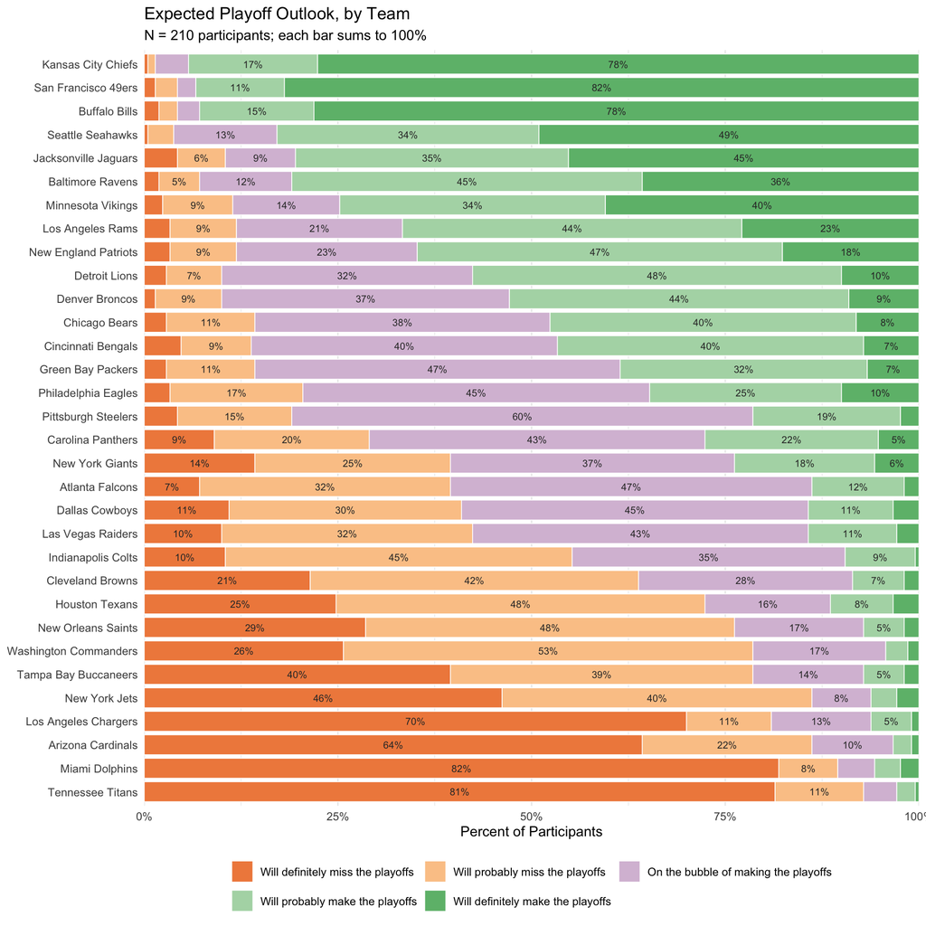

### Team Affinity

Participants placed every team into one of five categories describing how much they like the team (not how well it will perform). Teams are sorted by average affinity, with the most liked at the top.

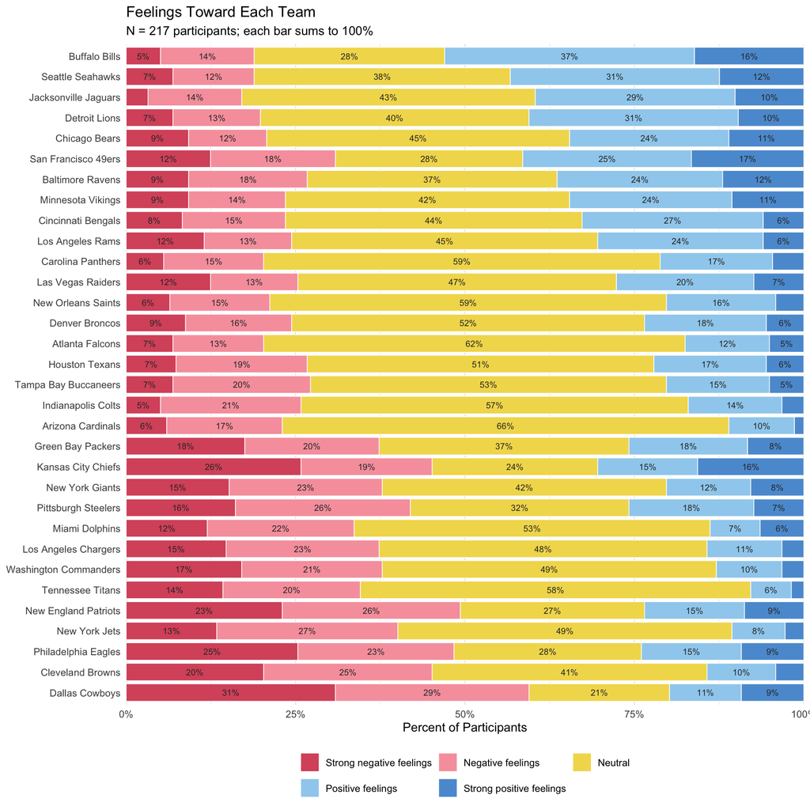

### Watching Habits

How often do you watch games where your favorite team is NOT playing?

| Response | N | Percent |
| --- | --- | --- |
| Rarely (a few times a season) | 10 | 4.6% |
| Sometimes (every few weeks) | 29 | 13.4% |
| Often (around once per week) | 60 | 27.6% |
| Very frequently (multiple times per week) | 118 | 54.4% |

During NFL season, how often do you plan your schedule around watching a game?

| Response | N | Percent |
| --- | --- | --- |
| Never | 4 | 1.8% |
| Rarely (a few times a season) | 16 | 7.4% |
| Sometimes (every few weeks) | 43 | 19.8% |
| Often (around once per week) | 89 | 41.0% |
| Very frequently (multiple times per week) | 65 | 30.0% |

Current Streaming/TV Subscriptions Used Primarily for NFL Games (N = 217; select all that apply)

| Service | N Selected | Percent Selected |
| --- | --- | --- |
| Amazon Prime | 139 | 64.1% |
| ESPN+ | 67 | 30.9% |
| FOX One | 19 | 8.8% |
| Fubo | 6 | 2.8% |
| Hulu + Live TV | 31 | 14.3% |
| Netflix | 74 | 34.1% |
| NFL Redzone | 58 | 26.7% |
| NFL Sunday Ticket | 44 | 20.3% |
| NFL+ (or NFL+ Premium) | 32 | 14.7% |
| Paramount+ | 62 | 28.6% |
| Peacock | 78 | 35.9% |
| Sling TV (orange or blue) | 8 | 3.7% |
| Youtube TV | 41 | 18.9% |

### Fandom

#### Wearing NFL Gear

How often do you wear NFL gear or merchandise on Sundays during football season?

| Response | N | Percent |
| --- | --- | --- |
| Never | 26 | 12.0% |
| Rarely (a few times a season) | 49 | 22.6% |
| Sometimes (about half of Sundays) | 62 | 28.6% |
| Often (most Sundays) | 43 | 19.8% |
| Always (every Sunday) | 37 | 17.1% |

How often do you wear NFL gear or merchandise on days other than Sunday?

| Response | N | Percent |
| --- | --- | --- |
| Never | 31 | 14.3% |
| Rarely (a few times a season) | 65 | 30.0% |
| Sometimes (a couple times per month) | 67 | 30.9% |
| Often (around once per week) | 43 | 19.8% |
| Very frequently (multiple times per week) | 11 | 5.1% |

#### Weekly Hours with NFL Content

Hours per week: Reading NFL news or articles

| Response | N | Percent |
| --- | --- | --- |
| I don't usually interact with this form of NFL content | 15 | 6.9% |
| Less than 1 hour per week | 80 | 36.9% |
| Between 1 and 3 hours per week | 94 | 43.3% |
| More than 3 hours per week | 28 | 12.9% |

Hours per week: Listening to NFL podcasts or radio shows (1 missing)

| Response | N | Percent |
| --- | --- | --- |
| I don't usually interact with this form of NFL content | 61 | 28.2% |
| Less than 1 hour per week | 77 | 35.6% |
| Between 1 and 3 hours per week | 55 | 25.5% |
| More than 3 hours per week | 23 | 10.6% |

Hours per week: Watching NFL analysis on TV shows (pregame, talk shows, etc.)

| Response | N | Percent |
| --- | --- | --- |
| I don't usually interact with this form of NFL content | 22 | 10.1% |
| Less than 1 hour per week | 73 | 33.6% |
| Between 1 and 3 hours per week | 91 | 41.9% |
| More than 3 hours per week | 31 | 14.3% |

Hours per week: Watching NFL videos online (highlights, YouTube clips, etc.) (3 missing)

| Response | N | Percent |
| --- | --- | --- |
| I don't usually interact with this form of NFL content | 15 | 7.0% |
| Less than 1 hour per week | 91 | 42.5% |
| Between 1 and 3 hours per week | 88 | 41.1% |
| More than 3 hours per week | 20 | 9.3% |

Hours per week: Looking at NFL betting content

| Response | N | Percent |
| --- | --- | --- |
| I don't usually interact with this form of NFL content | 55 | 25.3% |
| Less than 1 hour per week | 93 | 42.9% |
| Between 1 and 3 hours per week | 49 | 22.6% |
| More than 3 hours per week | 20 | 9.2% |

#### Fantasy Football and Game Attendance

Fantasy Football Leagues and NFL Games Attended

| Variable | Mean | SD | Min | Median | Max |
| --- | --- | --- | --- | --- | --- |
| Fantasy leagues: this season | 1.26 | 1.62 | 0 | 1 | 10 |
| Fantasy leagues: last season | 1.48 | 2.49 | 0 | 1 | 30 |
| Games attended: this season (or planned) | 0.94 | 1.43 | 0 | 0 | 9 |
| Games attended: last season | 1.02 | 1.64 | 0 | 0 | 12 |

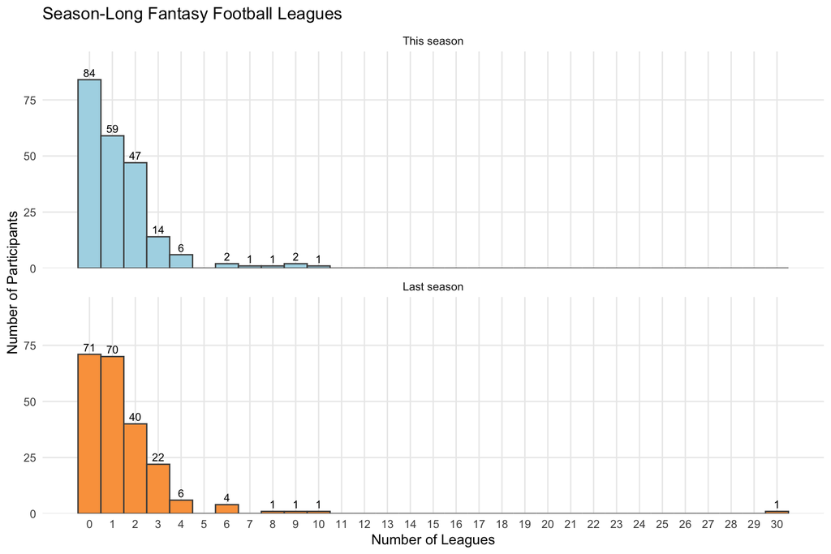

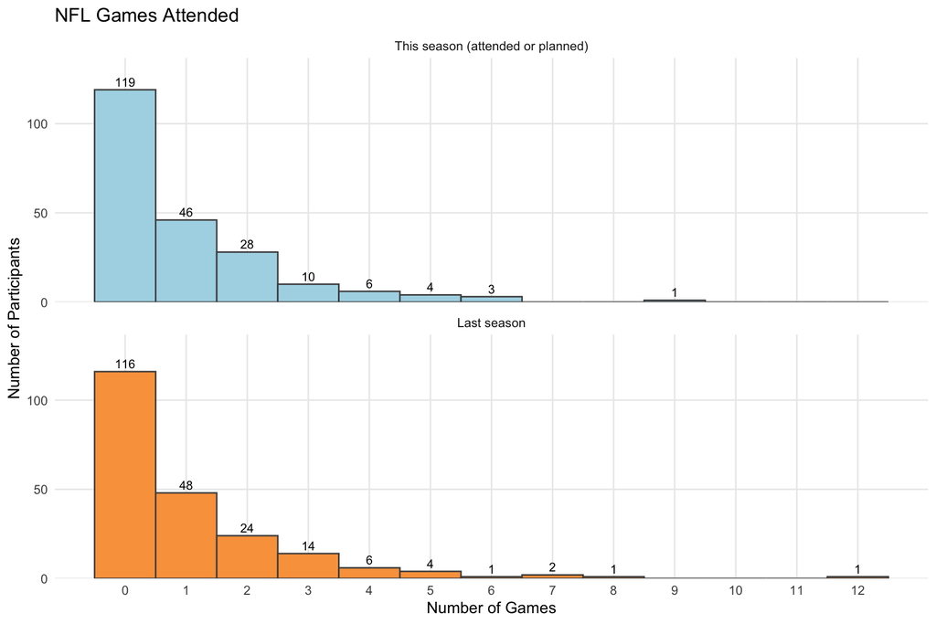

### Free Responses

20 Most Common Words in the Free Responses

| Word | Count |
| --- | --- |
| love | 66 |
| enjoy | 57 |
| started | 44 |
| dad | 34 |
| sports | 33 |
| cowboys | 32 |
| family | 32 |
| time | 32 |
| favorite | 30 |
| life | 30 |
| players | 30 |
| fun | 28 |
| grew | 28 |
| season | 26 |
| friends | 25 |
| week | 24 |
| kid | 23 |
| sport | 23 |
| study | 23 |
| people | 21 |